# Panel Data and Fixed Effects Methods for Ecology

Last updated: 2021-03-30

## Setup and Load Data

```r
library(tidyverse)
library(data.table)
library(fixest)
```

This data has already been cleaned and processed, and is ready to use. It corresponds to what we use in the paper.

```r
cdir <- getwd()
comb <- fread(paste(cdir,"/cleaned_comb_data.csv",sep=""),na.strings='NA')
```

## Working through different approaches

### Simple correlations in single years

A first place to start is looking correlations within a single year (i.e., using cross-sectional variation). we use all data and simple look at the correlation between log live mass and log richness in two years, 2012 and 2013. Throughout, we are going to cluster the standard errors by plot to acknowledge correlation in errors terms within a plot across years (though when we use only a single year of data, this is equivalent to using heteroskedasticity-robust errors).

```r
SimpleCorr2012 <- comb %>%
  filter(year==2012) %>%
  feols(log(live_mass) ~ log(rich), ., cluster = "newplotid")

SimpleCorr2013 <- comb %>%
  filter(year==2013) %>%
  feols(log(live_mass) ~ log(rich), ., cluster = "newplotid")

etable(SimpleCorr2012, SimpleCorr2013,
          cluster = "newplotid",
          drop = "Intercept",
          subtitles = c("Data in 2012", "Data in 2013"))
```

```
##                  SimpleCorr2012      SimpleCorr2013
##                    Data in 2012        Data in 2013
## Dependent Var.:  log(live_mass)      log(live_mass)
##
## log(rich)       0.1897 (0.1703) -0.3766*** (0.1006)
## _______________ _______________ ___________________
## S.E.: Clustered   by: newplotid       by: newplotid
## Observations                145                 121
## R2                      0.00951             0.08045
## Adj. R2                 0.00258             0.07272
```

In the results above, observe the results switches signs and significance between the two years. Is that whack?! Sure is, non-experimental cross-sectional data often has problems with omitted variable bias, as this simple comparison shows.

## STUFF FROM TUTORIAL BELOW

## Working Directory

By default, R will read and write files from its working directory. The status of the current directory can be found at the top of the Console window. You can also check the current working directory with the command `getwd()`.

### Best practices

Store all the files for an analysis (problem set) in a single directory. You might have the following directory structure:

- Quant_Meth_LifeSci
  - Lecture_Slides
  - Docs
  - Problem_Sets
    - PS_01
      - `PS_1.Rmd`
      - other files
    - PS_02
      - `PS_02.Rmd`
      - other files
    - PS_03, etc.

Then set the R working directory to the current active file using the RStudio menus: **Session $\rightarrow$ Set Working Directory $\rightarrow$ To Source File Location**.

Setting the working directory to the location of the current files will ensure that you can directly access the data files from the local folder, and that any files which are written will be in that directory.

As you get more comfortable with R, you can move files around, use sub-directories, etc. For now, keep it simple and store associated files in the same directory, even if this means duplicating files (which is something you definitely don’t want to do in general practice).

### Activity

Organize your files and set the working directory to the directory where this file and the required data files for this problem set are located. In the code chunk below set your working directory and use the ‘#’ to outline and describe the folder structure you have chosen

```r
# FIXME
getwd()
```

```
## [1] "C:/GitHub/NutNetCausalinf/example tutorial"
```

```r
# Should include folder structure here
# Our example looks like:
# - Quant_Meth_LifeSci
#     - Lecture_Slides
#     - Docs
#     - Problem_Sets
#         - PS_01
#             - `PS_1.Rmd`
#             - other files
#         - PS_02
#             - `PS_02.Rmd`
#             - other files
#         - PS_03, etc.
```

## Loading Packages

> In R, the fundamental unit of shareable code is the package. A package bundles together code, data, documentation, and tests, and is easy to share with others. As of January 2015, there were over 6,000[^1] packages available on the Comprehensive R Archive Network, or CRAN, the public clearing house for R packages. This huge variety of packages is one of the reasons that R is so successful: the chances are that someone has already solved a problem that you’re working on, and you can benefit from their work by downloading their package. (http://r-pkgs.had.co.nz/intro.html)

The `library()` function with the following syntax is used to load packages:

```r
library(tidyverse)
```

Packages much be installed before they can be loaded. If you get a message like:

> `Error in library("tidyverse") : there is no package called 'tidyverse'`

It means that the package is not installed. First install the package (note that the quotes are required):

```r
install.packages("tidyverse")
```

and then rerun the code chunk that includes the `library()`[^2] commands.

### Best practices (things to remember)

- It is best to install packages (e.g., `install.packages("cowplot")`) from the command line only. If you include this code in a R code chunk, you risk R trying to reinstall the package each time you knit your file.
- Packages only need to be installed once on each computer. They are stored locally.
- Packages do need to be loaded (`library()`) each time you restart R. Loaded packages are not persistent across R sessions.
- Load all of the packages you need at the start of a document to keep track of what packages your analysis needs.

### Activity

In the *Setup* code chunk at the beginning of this document, add code to load the following packages, which you will need for this problem set:

1. `tidyverse`
2. `readxl`
3. `cowplot`

Install these packages if you need to (see **Loading Packages** above for the installation syntax).

## Loading Data

Sexual size dimorphism (SSD) refers to the difference in size between males and females of the same species. Spiders show some of the most dramatic cases where females are larger than males.

The golden silk orb weaver (*Nephila clavipes*) is a species of spider that shows extreme SSD, in which males are about 2/3 smaller than females. This picture shows the size disparity between a female and male:

[figure not shown]

In contrast, in the wolf spider (*Pardosa ramulosa*), males and females do not show large size differences.

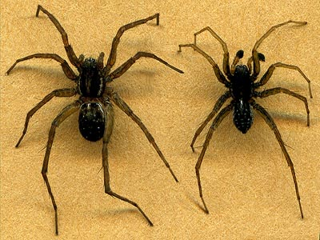

The file `Size_Dimorphism.xlsx` contains data on body mass and body length for males and females in these two species.

### Activity

Using the `read_excel()` function, load the file `Size_Dimorphism.xlsx` in R. Assign it to the object, `M`.

```r
#FIXME
M <- read.csv("Size_Dimorphism.csv")
```

## Exploring Data

Any time you load data from an external source (which is almost every time you are working with data), you should check to make sure that the data has been correctly imported.

You can use two functions to get a quick overview of the columns of a `data.frame` (or any R object, really), `str()` and `glimpse()`, each of which gives a list of the columns and their first few values.

### Activity

Type `str(M)` into the code chunk below and then compile or execute the code chunk in the R console.

```r
#FIXME
str(M)
```

```
## 'data.frame':    200 obs. of  4 variables:
##  $ Species   : Factor w/ 2 levels "Nephila_clavipes",..: 2 2 2 2 2 2 2 2 2 2 ...
##  $ Sex       : Factor w/ 2 levels "F","M": 2 2 2 2 2 2 2 2 2 2 ...
##  $ BodyLength: num  3.67 4.96 5.21 5.18 4.79 ...
##  $ BodyMass  : num  0.0534 0.1687 0.2237 0.1062 0.1466 ...
```

Using the output of `str(M)`, answer the following questions.

- How many rows are in the `data.frame` `M`?

> 200
- Does this agree with the number of rows in the Excel file? Why or why not?

## Number of Observations per Group

This experiment is balanced, meaning there are equal numbers of males and females in each species (50 of each).

### Activity

Check that this is the case by creating a logical and summing the resulting TRUE/FALSE vector. i.e. how many female *Nephila clavipes* are there?

```r
#FIXME
sum(M$Sex == 'F' & M$Species == 'Nephila_clavipes')
```

```
## [1] 50
```

```r
sum(M$Sex == 'M' & M$Species == 'Nephila_clavipes')
```

```
## [1] 50
```

```r
sum(M$Sex == 'F' & M$Species == 'Pardosa_ramulosa')
```

```
## [1] 50
```

```r
sum(M$Sex == 'M' & M$Species == 'Pardosa_ramulosa')
```

```
## [1] 50
```

```r
#FIXME
unique(M$Sex)
```

```
## [1] M F
## Levels: F M
```

```r
M[which(!(M$Sex %in% c('F', 'M'))), 'ID']
```

You could use the results of your `which()` calls to find and correct your excel file after making a back up copy just in case you make a mistake (or use version control!). If you were planning to do more editing in excel, this would be preferable. For this exercise will correct these within R here. We’ve given you the syntax for fixing one. Use this same format to fix the others. Run `unique()` again to make sure you got them all.

First change `eval=FALSE` to `eval=TRUE`. Changing this flag in the chunk header will cause RStudio to evaluate the chunk when it is knitting the document. When `eval` is `FALSE`, the chunk will be skipped. This is something that we need to do when writing the problem sets, so that they will compile.

```r
M$Sex[M$Sex == 'f'] <- 'F'
#FIXME
M$Sex[M$Sex == 'm'] <- 'M'
```

Now check the `Species` column in the same way. Fix any errors that you find.

```r
# FIXME
unique(M$Species)
```

```
## [1] Pardosa_ramulosa Nephila_clavipes
## Levels: Nephila_clavipes Pardosa_ramulosa
```

```r
M$Species[M$Species == 'Pardosa_ramuloso'] <- 'Pardosa_ramulosa'
M$Species[M$Species == 'Pardosa ramulosa'] <- 'Pardosa_ramulosa'
M$Species[M$Species == 'Pardosa_ramulosa '] <- 'Pardosa_ramulosa'

unique(M$Species)
```

```
## [1] Pardosa_ramulosa Nephila_clavipes
## Levels: Nephila_clavipes Pardosa_ramulosa
```

Saving yourself the trouble of doing this exercise is one big reason to be careful when you enter data!!

One last step, let’s write out your new, typo-free data. Look at the help for `write_csv()`, and write out your data to a new csv file named, `Size_Dimorphism_corrected.csv`.

```r
# FIXME
write_csv(M, "../Size_Dimorphism_corrected.csv")
```

Now read your new file back in as if this next section is a new script. Feel free to overwrite your previous object, `M`. This is a good idea to avoid confusion. Use `read_csv()`.

We prefer to use `write_csv()`, which is part of tidyverse, to R’s built-in `write.csv()` (note _ vs. .). `write_csv()` has some friendlier defaults settings.

```r
# FIXME
M <- read_csv("../Size_Dimorphism_corrected.csv")
```

## Data Filtering

A very common activity when you are analyzing data is to take subsets, be they subsets of rows or one or more columns (or both simultaneously). Gaining experience at this kind of filtering will make you much more efficient.

### Activity

To give you some practice filtering, filter your data in the following ways using base R functions. We will talk about they tidyverse version of these functions next week, but if you want to get ahead you can google these and try them here. You do not need to save the resulting `data.frame`s.

1. All *Pardosa ramulosa*
2. All females of both species
3. Body mass and sex for *Nephila clavipes*
4. Rows 1-50 (either using base R or the `slice()` function from tidyverse [use `?slice` to load the help file])
5. Mass of the largest female (by mass) in each species
6. Male *Pardosa ramulosa* with body lengths less than 4 or greater than 6

```r
#FIXME
# 1
M[M$Species == "Pardosa_ramulosa", ]
```

```
## # A tibble: 100 x 4
##    Species          Sex   BodyLength BodyMass
##    <chr>            <chr>      <dbl>    <dbl>
##  1 Pardosa_ramulosa M           3.67   0.0534
##  2 Pardosa_ramulosa M           4.96   0.169
##  3 Pardosa_ramulosa M           5.21   0.224
##  4 Pardosa_ramulosa M           5.18   0.106
##  5 Pardosa_ramulosa M           4.79   0.147
##  6 Pardosa_ramulosa M           6.05   0.221
##  7 Pardosa_ramulosa M           3.97   0.0986
##  8 Pardosa_ramulosa M           2.75   0.0249
##  9 Pardosa_ramulosa M           4.22   0.0716
## 10 Pardosa_ramulosa M           3.41   0.0434
## # ... with 90 more rows
```

```r
M %>% filter(Species == "Pardosa_ramulosa")
```

```
## # A tibble: 100 x 4
##    Species          Sex   BodyLength BodyMass
##    <chr>            <chr>      <dbl>    <dbl>
##  1 Pardosa_ramulosa M           3.67   0.0534
##  2 Pardosa_ramulosa M           4.96   0.169
##  3 Pardosa_ramulosa M           5.21   0.224
##  4 Pardosa_ramulosa M           5.18   0.106
##  5 Pardosa_ramulosa M           4.79   0.147
##  6 Pardosa_ramulosa M           6.05   0.221
##  7 Pardosa_ramulosa M           3.97   0.0986
##  8 Pardosa_ramulosa M           2.75   0.0249
##  9 Pardosa_ramulosa M           4.22   0.0716
## 10 Pardosa_ramulosa M           3.41   0.0434
## # ... with 90 more rows
```

```r
# 2
M[M$Sex == "F", ]
```

```
## # A tibble: 100 x 4
##    Species          Sex   BodyLength BodyMass
##    <chr>            <chr>      <dbl>    <dbl>
##  1 Pardosa_ramulosa F           6.44   0.319
##  2 Pardosa_ramulosa F           5.93   0.465
##  3 Pardosa_ramulosa F           4.59   0.0679
##  4 Pardosa_ramulosa F           6.91   0.252
##  5 Pardosa_ramulosa F           6.12   0.113
##  6 Pardosa_ramulosa F           7.91   0.255
##  7 Pardosa_ramulosa F           6.04   0.252
##  8 Pardosa_ramulosa F           6.80   0.201
##  9 Pardosa_ramulosa F           5.14   0.161
## 10 Pardosa_ramulosa F           4.94   0.0960
## # ... with 90 more rows
```

```r
M %>% filter(Sex == "F")
```

```
## # A tibble: 100 x 4
##    Species          Sex   BodyLength BodyMass
##    <chr>            <chr>      <dbl>    <dbl>
##  1 Pardosa_ramulosa F           6.44   0.319
##  2 Pardosa_ramulosa F           5.93   0.465
##  3 Pardosa_ramulosa F           4.59   0.0679
##  4 Pardosa_ramulosa F           6.91   0.252
##  5 Pardosa_ramulosa F           6.12   0.113
##  6 Pardosa_ramulosa F           7.91   0.255
##  7 Pardosa_ramulosa F           6.04   0.252
##  8 Pardosa_ramulosa F           6.80   0.201
##  9 Pardosa_ramulosa F           5.14   0.161
## 10 Pardosa_ramulosa F           4.94   0.0960
## # ... with 90 more rows
```

```r
# 3
M[M$Species == "Nephila_clavipes", c("BodyMass", "Sex")]
```

```
## # A tibble: 100 x 2
##    BodyMass Sex
##       <dbl> <chr>
##  1     6.36 M
##  2    12.1  M
##  3     6.39 M
##  4     3.91 M
##  5     2.01 M
##  6    12.8  M
##  7     2.44 M
##  8     7.69 M
##  9    11.6  M
## 10     2.93 M
## # ... with 90 more rows
```

```r
M %>% filter(Species == "Nephila_clavipes") %>%
  select(BodyMass, Sex)
```

```
## # A tibble: 100 x 2
##    BodyMass Sex
##       <dbl> <chr>
##  1     6.36 M
##  2    12.1  M
##  3     6.39 M
##  4     3.91 M
##  5     2.01 M
##  6    12.8  M
##  7     2.44 M
##  8     7.69 M
##  9    11.6  M
## 10     2.93 M
## # ... with 90 more rows
```

```r
# 4
M[1:50, ]
```

```
## # A tibble: 50 x 4
##    Species          Sex   BodyLength BodyMass
##    <chr>            <chr>      <dbl>    <dbl>
##  1 Pardosa_ramulosa M           3.67   0.0534
##  2 Pardosa_ramulosa M           4.96   0.169
##  3 Pardosa_ramulosa M           5.21   0.224
##  4 Pardosa_ramulosa M           5.18   0.106
##  5 Pardosa_ramulosa M           4.79   0.147
##  6 Pardosa_ramulosa M           6.05   0.221
##  7 Pardosa_ramulosa M           3.97   0.0986
##  8 Pardosa_ramulosa M           2.75   0.0249
##  9 Pardosa_ramulosa M           4.22   0.0716
## 10 Pardosa_ramulosa M           3.41   0.0434
## # ... with 40 more rows
```

```r
M %>% slice(1:50)
```

```
## # A tibble: 50 x 4
##    Species          Sex   BodyLength BodyMass
##    <chr>            <chr>      <dbl>    <dbl>
##  1 Pardosa_ramulosa M           3.67   0.0534
##  2 Pardosa_ramulosa M           4.96   0.169
##  3 Pardosa_ramulosa M           5.21   0.224
##  4 Pardosa_ramulosa M           5.18   0.106
##  5 Pardosa_ramulosa M           4.79   0.147
##  6 Pardosa_ramulosa M           6.05   0.221
##  7 Pardosa_ramulosa M           3.97   0.0986
##  8 Pardosa_ramulosa M           2.75   0.0249
##  9 Pardosa_ramulosa M           4.22   0.0716
## 10 Pardosa_ramulosa M           3.41   0.0434
## # ... with 40 more rows
```

```r
# 5
max(M[M$Sex == 'F' & M$Species == 'Pardosa_ramulosa', 'BodyMass'])
```

```
## [1] 0.8763067
```

```r
max(M[M$Sex == 'F' & M$Species == 'Nephila_clavipes', 'BodyMass'])
```

```
## [1] 1283.286
```

```r
M %>% filter(Sex == "F") %>%
  group_by(Species) %>%
  summarize(max_BodyMass = max(BodyMass))
```

```
## # A tibble: 2 x 2
##   Species          max_BodyMass
##   <chr>                   <dbl>
## 1 Nephila_clavipes     1283.
## 2 Pardosa_ramulosa        0.876
```

```r
# 6
M[M$Species == "Pardosa_ramulosa" &
    M$Sex == "M" &
    (M$BodyLength < 4 | M$BodyLength > 6), ]
```

```
## # A tibble: 22 x 4
##    Species          Sex   BodyLength BodyMass
##    <chr>            <chr>      <dbl>    <dbl>
##  1 Pardosa_ramulosa M           3.67   0.0534
##  2 Pardosa_ramulosa M           6.05   0.221
##  3 Pardosa_ramulosa M           3.97   0.0986
##  4 Pardosa_ramulosa M           2.75   0.0249
##  5 Pardosa_ramulosa M           3.41   0.0434
##  6 Pardosa_ramulosa M           6.46   0.211
##  7 Pardosa_ramulosa M           7.14   0.621
##  8 Pardosa_ramulosa M           7.13   0.168
##  9 Pardosa_ramulosa M           3.84   0.0522
## 10 Pardosa_ramulosa M           3.60   0.0832
## # ... with 12 more rows
```

```r
M %>% filter(Species == "Pardosa_ramulosa" & Sex == "M") %>%
  filter(BodyLength < 4 | BodyLength > 6)
```

```
## # A tibble: 22 x 4
##    Species          Sex   BodyLength BodyMass
##    <chr>            <chr>      <dbl>    <dbl>
##  1 Pardosa_ramulosa M           3.67   0.0534
##  2 Pardosa_ramulosa M           6.05   0.221
##  3 Pardosa_ramulosa M           3.97   0.0986
##  4 Pardosa_ramulosa M           2.75   0.0249
##  5 Pardosa_ramulosa M           3.41   0.0434
##  6 Pardosa_ramulosa M           6.46   0.211
##  7 Pardosa_ramulosa M           7.14   0.621
##  8 Pardosa_ramulosa M           7.13   0.168
##  9 Pardosa_ramulosa M           3.84   0.0522
## 10 Pardosa_ramulosa M           3.60   0.0832
## # ... with 12 more rows
```

## Plotting Histograms

To start looking at sexual size dimorphism, we will make some histograms. This is the easiest method to visualize univariate data.

### Activity

The `cowplot` has a nice built-in ggplot theme that produces nice plots (there are lots of ggplot themes available). A good place to set this is in the setup chunk at the top of this document. Go there and add this code (without the tic marks): `theme_set(theme_cowplot())`.

Start with a histogram of body length overall. Follow the code in the lectures if you need to.

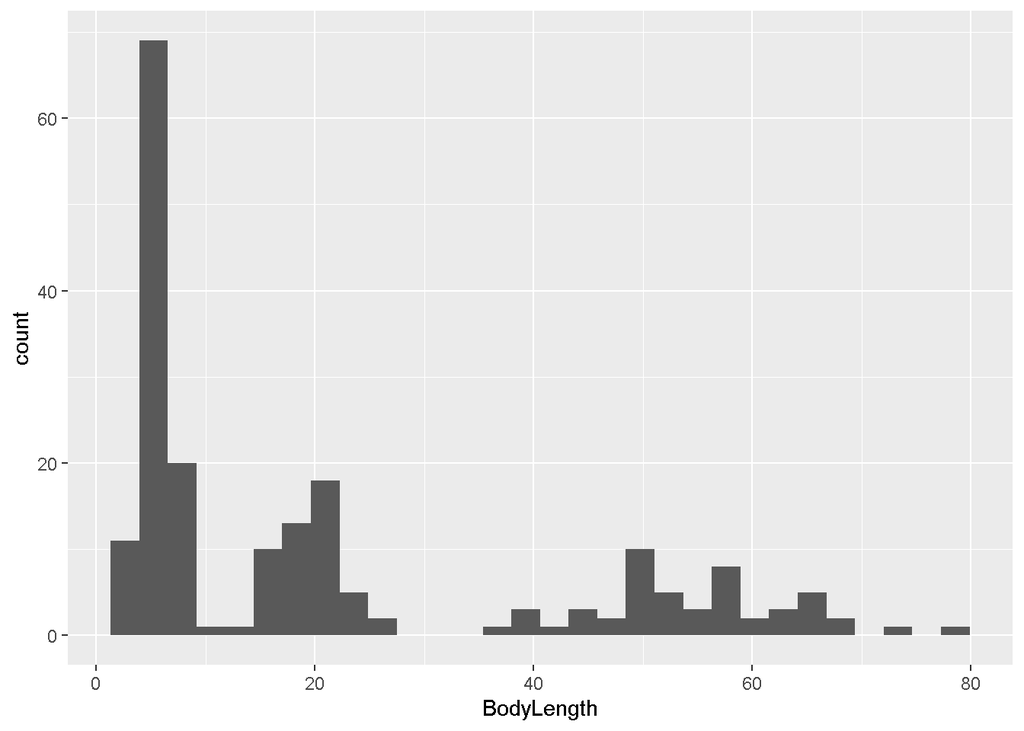

```r
#FIXME
ggplot(M, aes(BodyLength)) +
  geom_histogram()
```

There are some obvious groupings here, but we don’t know which species or sex the clusters represent. We need to separate both species and sex. One approach is to make a plot for each species with `fill` coding for sex (this is analogous to using color, but works better with histograms). Try this.

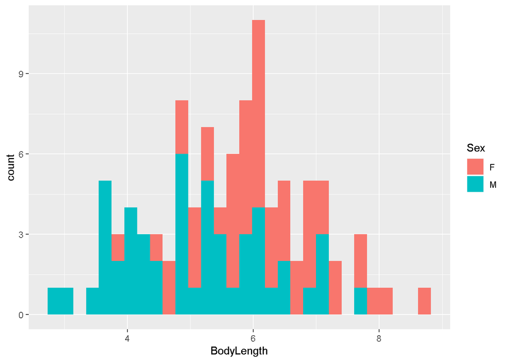

```r
#FIXME
M %>%
  filter(Species == 'Pardosa_ramulosa') %>%
  ggplot(aes(BodyLength, fill = Sex)) +
  geom_histogram()
```

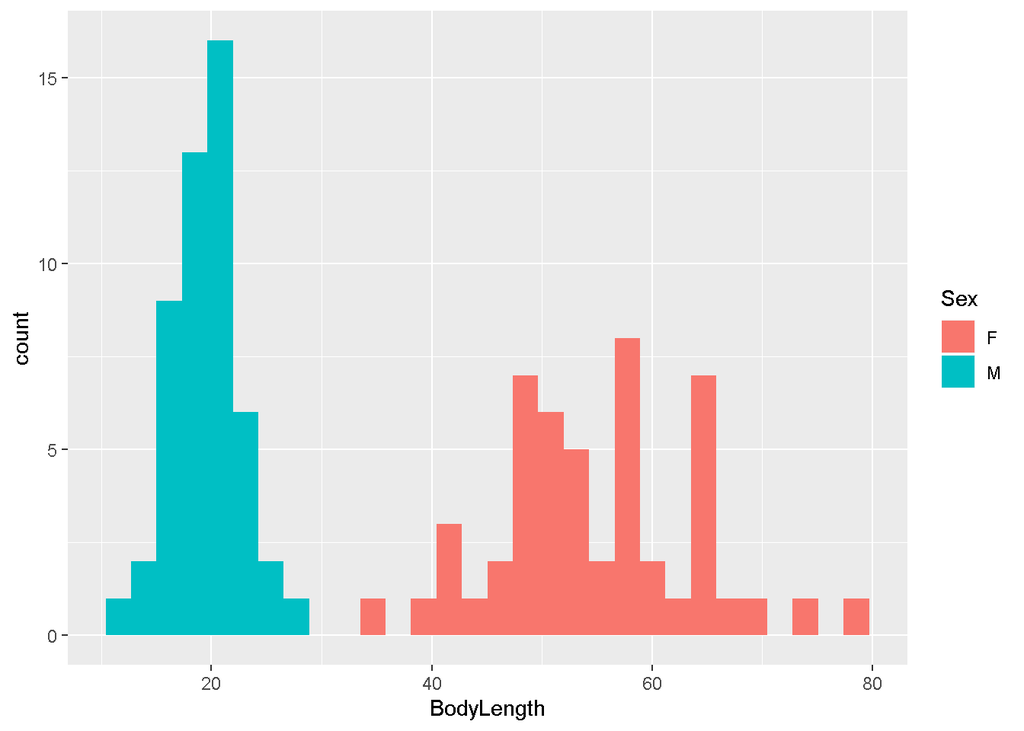

```r
M %>%
  filter(Species == 'Nephila_clavipes') %>%
  ggplot(aes(BodyLength, fill = Sex)) +
  geom_histogram()
```

You will get a message saying that “`stat_bin()` using `bins = 30`. Pick better value with `binwidth`.” That just means that you are using the default bin size for your histograms. In some situations, you would want to specify that value explicitly. For now, using the default value of 30 is fine. Later you can use the `binwidth` option to choose a different size.

We could also visualize all groups with `facet_grid()`. Here is an example:

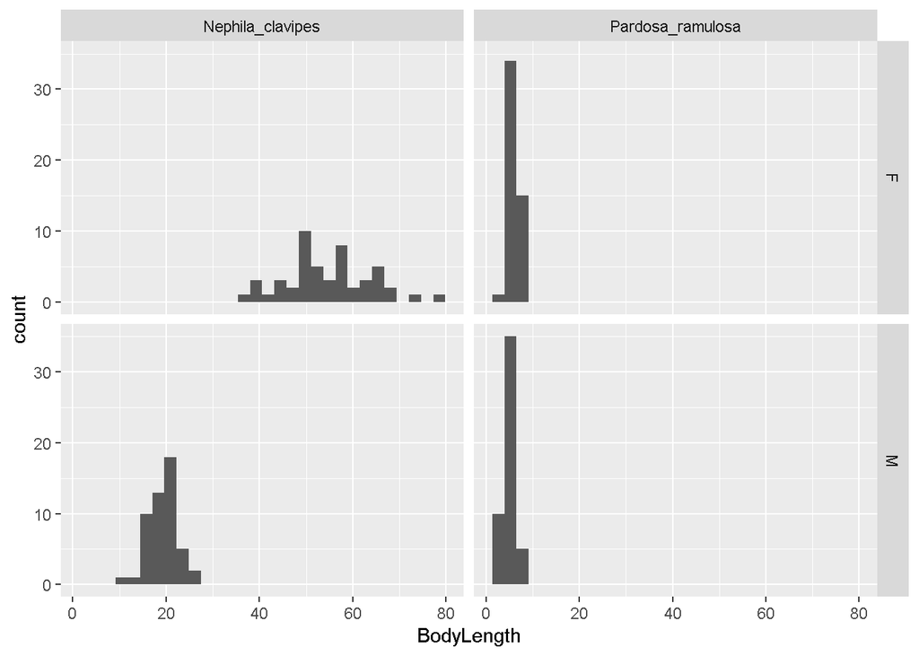

```r
ggplot(M, aes(BodyLength)) +
  geom_histogram() +
  facet_grid(Sex ~ Species)
```

`facet_grid()` can take 1 or two arguments. The argument before `~` splits by rows, and after `~` splits by columns. If you only want one or the other use `.`. See the lecture slides for an example.

With this you can clearly see SSD in *Nephila* but not in *Pardosa*.

## Scatterplot

You might be interested in the relationship between body length and body mass. Scatterplots are the most common way to visualize such bivariate relationships.

### Activity

Create a scatterplot of body length and body mass. Use color to show Sex and facet by Species. Put body length on the x axis. Add axis labels, but don’t worry about units for now.

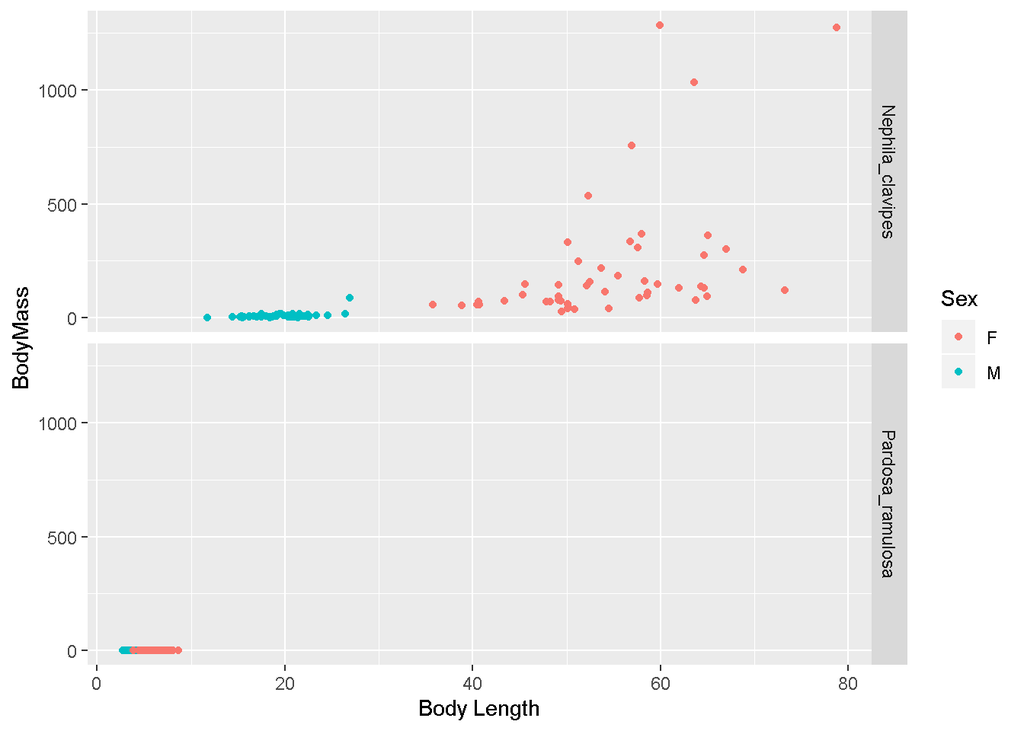

```r
# FIXME
ggplot(M, aes(x = BodyLength, y = BodyMass, color = Sex)) +
  geom_point() +
  facet_grid(Species ~ .) +
  labs(x = "Body Length", y = "BodyMass")
```

Describe the patterns you observe. Do you think this is a useful visualization? Why or why not?

> Not really that useful. The data for *Pardosa* is all smashed down to ~0 on the y axis, as is the male data for *Nephila*. The *Nephila* female are the only ones with any variation, which looks like it is increasing as body length increases.

Because body length and body mass are related by an exponential power, if we take advantage of the math of logarithms and log-transform the data, that will linearize the relationship. Ignoring the y-intercepts:

$$Mass \propto Length^b$$
$$\log(Mass) \propto b \log(Length)$$

Make two new variables that are the log10-transformations of body length and body mass using `mutate()` and plot the data again. Look at the help for `mutate` for hints. Then add new axis labels.

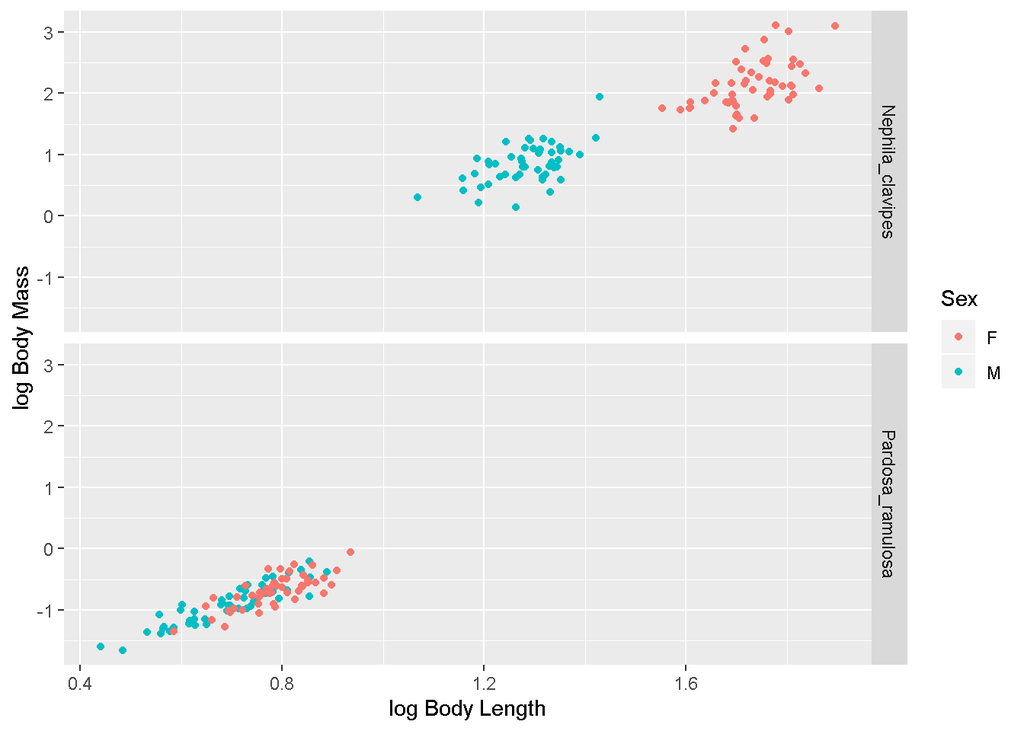

```r
#FIXME
M <- mutate(M, logMass = log10(BodyMass),
            logLength = log10(BodyLength))

# or with a pipe

M <- M %>% mutate(logMass = log10(BodyMass),
                  logLength = log10(BodyLength))

# Scatterplot
ggplot(M, aes(x = logLength, y = logMass, color = Sex)) +
  geom_point() +
  facet_grid(Species ~ .) +
  labs(x = "log Body Length", y = "log Body Mass")
```

What does this plot tell you? Do you think this is a more effective visualization of the data?

> There is a positive, linear relationship between log(mass) and log(body length). In *Pardosa*, the female and male distributions overlap almost completely. In *Nephila*, there is a large separation between the females and males.

Now add lines of best fit and transparency (`alpha`) to your points.

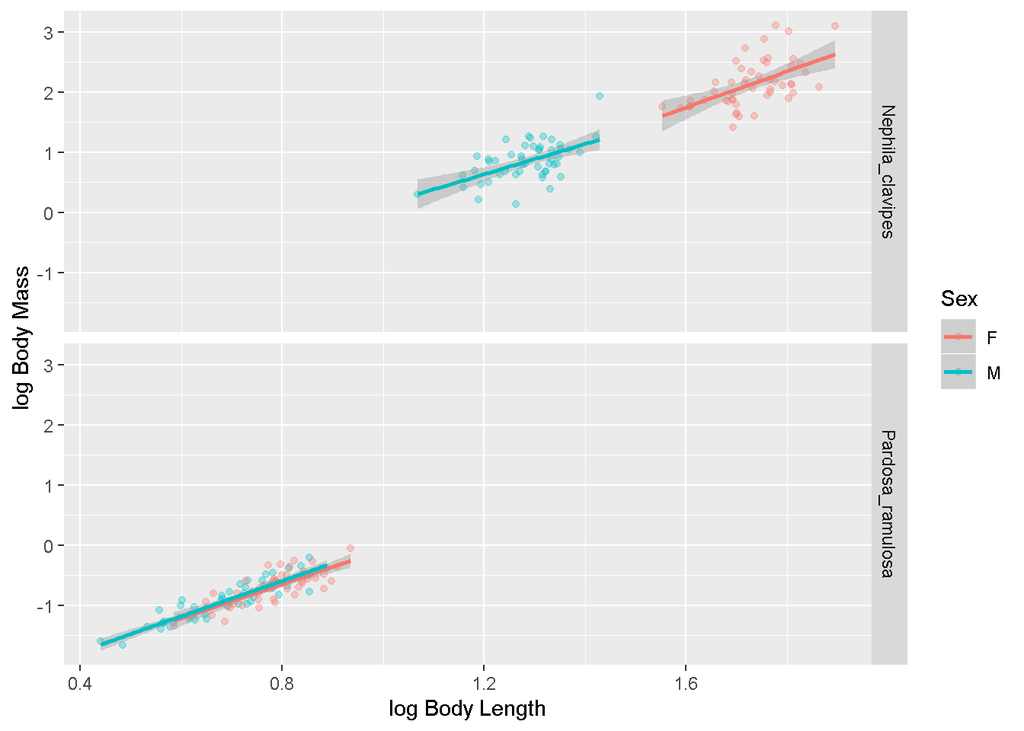

```r
#FIXME
ggplot(M, aes(x = logLength, y = logMass, color = Sex)) +
  geom_point(alpha = 1/3) +
  geom_smooth(method = 'lm') +
  facet_grid(Species ~ .) +
  labs(x = "log Body Length", y = "log Body Mass")
```

What do these regression lines tell you?

> The slopes of the lines are nearly identical, which suggests that the linear relationships between log length and log mass is probably equal across the four groups.
[^1]: There are >10,000 now
[^2]: Inside the call to `library()`, package names do not need to be quoted (but they can be without incident). `install.packages()`, on the other hand, expects to receive a string or vector of strings, so you do need quotes.